# Tidyverse

Today we will learn some useful data manipulation functions in R. A lot of this stuff can be done with base R functions, but if you don’t know how to do it in base R, using tidyverse is probably easier to learn! I will be around to help, but please also help each other where possible!

There is a useful cheat sheet, which you might want to have open for the whole session, available at https://www.rstudio.com/wp-content/uploads/2015/02/data-wrangling-cheatsheet.pdf

And of course this book on R for data science is useful too: http://r4ds.had.co.nz/

Here is a list of things we will learn today:

1. Filtering observations using `filter()`
2. Selecting variables using `select()`
3. Changing data from wide to long format and vice versa, using `gather()` and `spread()`
4. Merging different dataframes together with the `bind()` and `join()` functions
5. Using the pipe operator `%>%` to write tidy code and group observation with `group_by()`
6. Calculating new variables with `mutate()` and `summarise()`

There are lots of functions in different packages, and altogether they are called tidyverse. The two packages we will use today are dplyr and tidyr, but you can download all of them in one go too. we will not use every single function, or different way of using them, but instead focus on the main ones that will hopefully come in handy!

**PLEASE DO NOT TRY TO DOWNLOAD ALL** `tidyverse` **PACKAGES AS IT MIGHT TAKE A LONG LONG TIME, SO STICK TO** `dplyr`, `tidyr` **AND** `ggplot` **FOR NOW!!!**

```r
install.packages("dplyr", "tidyr", "ggplot")
library(dplyr, tidyr, ggplot)
```

We will use different datasets that are built into R. I usually look at the data to start with, for example using `str()` and `summary()`.

We will start using the dataset `starwars`.

```r
str(starwars)
summary(starwars)
```

The functions follow the normal form in R, for example, we can change column names using `rename()`:

```r
starwarsm <- rename(starwars, mass_in_kg = mass)
```

> What do the functions `distinct()` and `arrange()` do?

## filter

One of the simplest and most useful functions is `filter()`.

`filter` will retain or remove rows in your dataset, according to conditions you set:

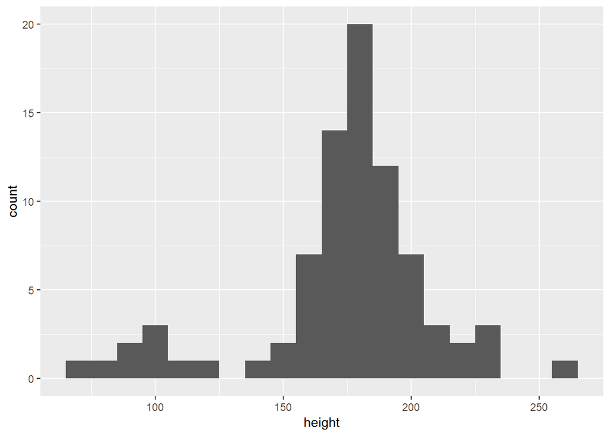

```r
ggplot(data = starwars, aes(x = height)) +
  geom_histogram(binwidth = 10) ## this makes a histogram using ggplot, which we will learn about at another session
```

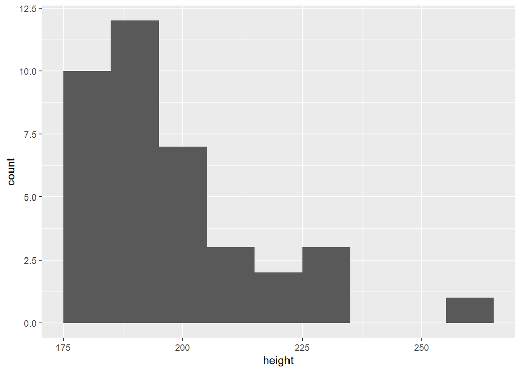

```r
tall <- filter(starwars, height > 180)
# this creates a new dataset called tall, which are all values from dataset starwars where height is above 180

ggplot(data = tall, aes(x = height)) +
  geom_histogram(binwidth = 10)
```

> Exercise: Create a dataframe where all heights are below 150, and check it worked using `ggplot()`  
> We can also look for exact values. Sometimes you need to use `=`, sometimes `==`:

```r
height180 <- filter(starwars, height == 180)
summary(height180$height)
```

The structure for NA values is slightly different (`x = NA` doesn’t work):

```r
summary(factor(starwars$hair_color))
# hair_color contains 5 rows with NA values

hairNA<-filter(starwars, is.na(hair_color))
# In this case we keep those rows where hair_color is NA

summary(hairNA$hair_color)
```

> Can you create a dataframe where the variable hair_color is never NA? The cheat sheet might help.

> In the starwars dataset, retain only observations where eye_color is red Can you also create a new dataframe with three colours? You might need to use this operator: `%in%`

## select

The `select` function can be used to include or exclude columns from the dataset:

```r
str(starwars)

sw2<-select(starwars, -height)
# this will make a new dataframe, without the variable height

str(sw2)

sw3<-select(starwars, homeworld, species)
# this will make a new dataframe, with only the variables homeworld and species

str(sw3)
```

> Using starwars, create a new dataframe where all variables start with h.

There are lots of other ways of using `filter` and `select`, all listed on the cheat sheet.

## Reshaping data

```r
table4b
```

We might not want each year as a column heading in our dataframe, but have both years in a new column called year. we would also need another new variable, which would list the values currently in 1999 and 2000, we will call it population:

```r
table4bnew <- gather(table4b, "year", "population", 2:3)
table4bnew
```

> Can you reverse what you did, and put the data back into the original format? Use the function `spread()`.

> In the starswars dataset, can you combine hair_color, skin_color and eye_color into two new variables: typeofcol and col?

## Merging dataframes

tidyverse has the functions `bind_cols` and `bind_rows` which are similar to cbind and rbind. They do as they say - they bind rows or columns of dataframes together.

It is also possible to merge two dataframes based on one or more columns.

First we need to create two dataframes that have some overlapping values in the same column, using state.name, state.area and state.region:

```r
summary(state.name)
summary(state.area)
summary(state.region)

## first we need to turn them into dataframes:

staten <- data_frame(state.name)
statea <- data_frame(state.area)
stater <- data_frame(state.region)

state2 <- bind_cols(staten, statea) #we just stick the two together
state3 <- bind_cols(staten, stater)

# Now we create some overlap between these two dataframes, to learn how join() works:

state2 <- slice(state2, 1:30) #slice selects the rows 1 to 30 in this case
state3 <- slice(state3, 21:50)
```

Now we can make different datasets with different functions. When I use these functions I check and double check what exactly each function does, as it can get a bit confusing:

```r
state4 <- left_join(state2, state3, by = "state.name")
# this will keep all the data in state2, and will add region from state3 to the states that appear in both datasets. If the state is not in state3, the region will be NA
str(state4)

state5<-inner_join(state2, state3, by = "state.name")
# this will only keep states that appear in both datasets
str(state5)
```

> Can you join all of the data in state2 and state3 together, so you end up with 3 columns and 50 rows, and probably a few NAs?

> What does anti_join() do? Try it with state2 and state3.

I have used these functions loads to merge species level data, which is handy as species names are (supposedly) standardised!

## Piping

If we need to do a lot of data manipulation in a dataframe, we can use piping, with the piping operator `%>%`. Have a look at this SHOCKINGLY UNTIDY example:

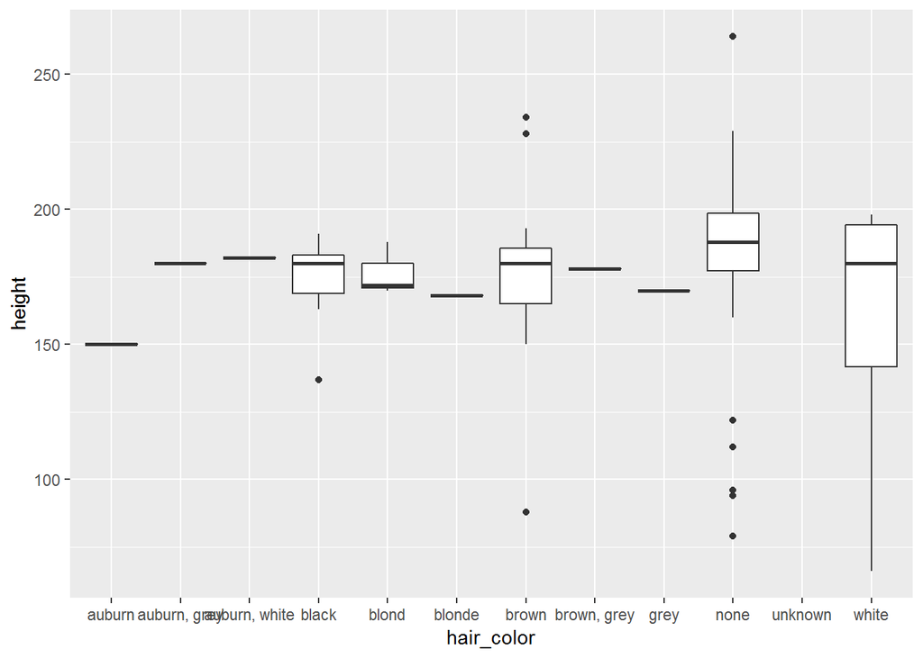

```r
starwars2 <- filter(starwars, !is.na(hair_color))
starwars2 <- select(starwars2, -eye_color)
starwars2 <- arrange(starwars2, -height)

ggplot(starwars2, aes(x = hair_color, y = height)) +
  geom_boxplot()
```

If we use piping, we can reduce the code and have less opportunities for misspellings etc. I have written the code below with pipes, but it does exactly the same as the code above:

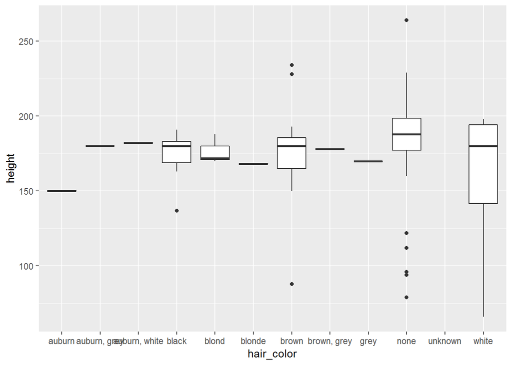

```r
starwars2 <- starwars %>%
  filter(!is.na(hair_color)) %>%
  select(-eye_color) %>%
  arrange(-height)
# rather than having to write starwars2 at the start of each bracket, we don't need to write it apart from the start

ggplot(starwars2, aes(x = hair_color, y = height)) +
  geom_boxplot()
```

Have a look at this code:

```r
starwars3 <- filter(starwars, eye_color == "brown")
starwars3 <- select(starwars3, -birth_year)
starwars3 <- sample_n(starwars3, 100, replace = TRUE)
```

> Can you turn the above horrible code into a nice pipe? Hint: the keyboard shortcut for the pipe operator is Ctrl + Shift + M

## mutate

We can use `mutate` to calculate new variables, based on others we already have:

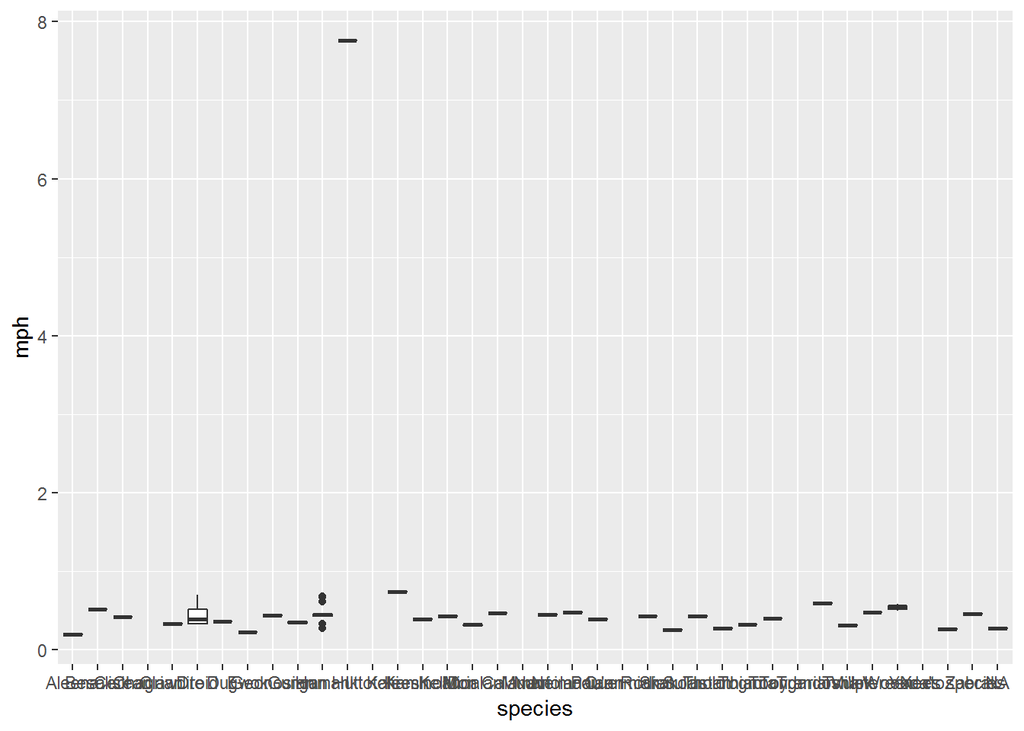

```r
starwars <- mutate(starwars, mph = mass / height)
# the new variable is called mph

ggplot(starwars, aes(x = species, y = mph)) +
  geom_boxplot()
```

`mutate` can also change variables according to conditions we set:

```r
str(starwars)
starwars<-mutate_if(starwars, is.character, as.factor)
str(starwars)
# this will turn all variables that are factors into characters, or vice versa:
```

> Change the variable homeworld into a factor.

We can also easily group observations with piping, and calculate summary statistics:

```r
starwars %>%
  group_by(species) %>%
  summarise(meanh = mean(height))
```

> Can you calculate the median mass by homeworld?

And this is the end of this tutorial! **WELL DONE YOU MADE IT THROUGH!**